# Bayes Aplicado ENIGH

Hector Najera y Curtis Huffman

13/04/2023

# Hipótesis en estadística Bayesiana

Hemos visto algunas de las limitaciones del paradigma de la hipótesis nula.

- El logro educativo tiene un efecto positivo en los ingresos de los hogares (Signo)
- El efecto es proporcional según niveles educativos

Vamos a utilizar datos de la ENIGH 2018. Usaremos el nivel educativo de la jefatura del hogar y el ingreso corriente total per cápita.

```r
library(haven)
library(dplyr)
library(brms)
D<-read_dta("pobreza_18.dta")
```

```r
M1<-brm(ictpc ~ 1 + niv_edexpjh + tamhogesc, family="gaussian",
        prior = c(set_prior("normal(0,10000)", class = "b")),
        cores=4, iter=1000,
        threads = threading(14, grainsize = 100),backend = "cmdstanr", chains=2, data=D)
```

```
## Running MCMC with 2 chains, at most 4 in parallel, with 14 thread(s) per chain...
##
## Chain 1 Iteration:   1 / 1000 [  0%]  (Warmup)
## Chain 2 Iteration:   1 / 1000 [  0%]  (Warmup)
## Chain 1 Iteration: 100 / 1000 [ 10%]  (Warmup)
## Chain 2 Iteration: 100 / 1000 [ 10%]  (Warmup)
## Chain 2 Iteration: 200 / 1000 [ 20%]  (Warmup)
## Chain 2 Iteration: 300 / 1000 [ 30%]  (Warmup)
## Chain 1 Iteration: 200 / 1000 [ 20%]  (Warmup)
## Chain 2 Iteration: 400 / 1000 [ 40%]  (Warmup)
## Chain 1 Iteration: 300 / 1000 [ 30%]  (Warmup)
## Chain 2 Iteration: 500 / 1000 [ 50%]  (Warmup)
## Chain 2 Iteration: 501 / 1000 [ 50%]  (Sampling)
## Chain 1 Iteration: 400 / 1000 [ 40%]  (Warmup)
## Chain 2 Iteration: 600 / 1000 [ 60%]  (Sampling)
## Chain 1 Iteration: 500 / 1000 [ 50%]  (Warmup)
## Chain 1 Iteration: 501 / 1000 [ 50%]  (Sampling)
## Chain 2 Iteration: 700 / 1000 [ 70%]  (Sampling)
## Chain 1 Iteration: 600 / 1000 [ 60%]  (Sampling)
## Chain 2 Iteration: 800 / 1000 [ 80%]  (Sampling)
## Chain 1 Iteration: 700 / 1000 [ 70%]  (Sampling)
## Chain 2 Iteration: 900 / 1000 [ 90%]  (Sampling)
## Chain 1 Iteration: 800 / 1000 [ 80%]  (Sampling)
## Chain 1 Iteration: 900 / 1000 [ 90%]  (Sampling)
## Chain 2 Iteration: 1000 / 1000 [100%]  (Sampling)
## Chain 2 finished in 9.6 seconds.
## Chain 1 Iteration: 1000 / 1000 [100%]  (Sampling)
## Chain 1 finished in 9.8 seconds.
##
## Both chains finished successfully.
## Mean chain execution time: 9.7 seconds.
## Total execution time: 9.9 seconds.
```

```r
summary(M1)
```

```
##  Family: gaussian
##   Links: mu = identity; sigma = identity
## Formula: ictpc ~ 1 + niv_edexpjh + tamhogesc
##    Data: D (Number of observations: 20000)
##   Draws: 2 chains, each with iter = 1000; warmup = 500; thin = 1;
##          total post-warmup draws = 1000
##
## Population-Level Effects:
##             Estimate Est.Error l-95% CI u-95% CI Rhat Bulk_ESS Tail_ESS
## Intercept    3418.16    171.20  3100.99  3753.36 1.00      881      846
## niv_edexpjh  1304.49     44.12  1217.30  1390.09 1.00      825      809
## tamhogesc    -395.89     31.99  -454.99  -331.51 1.00     1043      701
##
## Family Specific Parameters:
##       Estimate Est.Error l-95% CI u-95% CI Rhat Bulk_ESS Tail_ESS
## sigma  7601.52     40.00  7522.11  7682.47 1.00     1584      875
##
## Draws were sampled using sample(hmc). For each parameter, Bulk_ESS
## and Tail_ESS are effective sample size measures, and Rhat is the potential
## scale reduction factor on split chains (at convergence, Rhat = 1).
```

```r
library(bayesplot)
library(tidybayes)
get_variables(M1)
```

```
##  [1] "b_Intercept"   "b_niv_edexpjh" "b_tamhogesc"   "sigma"
##  [5] "lprior"        "lp__"          "accept_stat__" "treedepth__"
##  [9] "stepsize__"    "divergent__"   "n_leapfrog__"  "energy__"
```

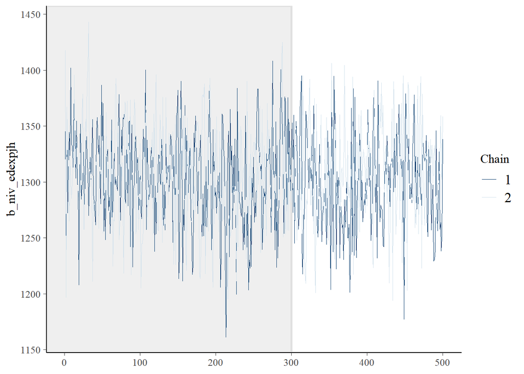

```r
color_scheme_set("mix-blue-pink")
p <- mcmc_trace(M1,  pars = c("b_niv_edexpjh" ), n_warmup = 300,
                facet_args = list(nrow = 2))
p + facet_text(size = 15)
```

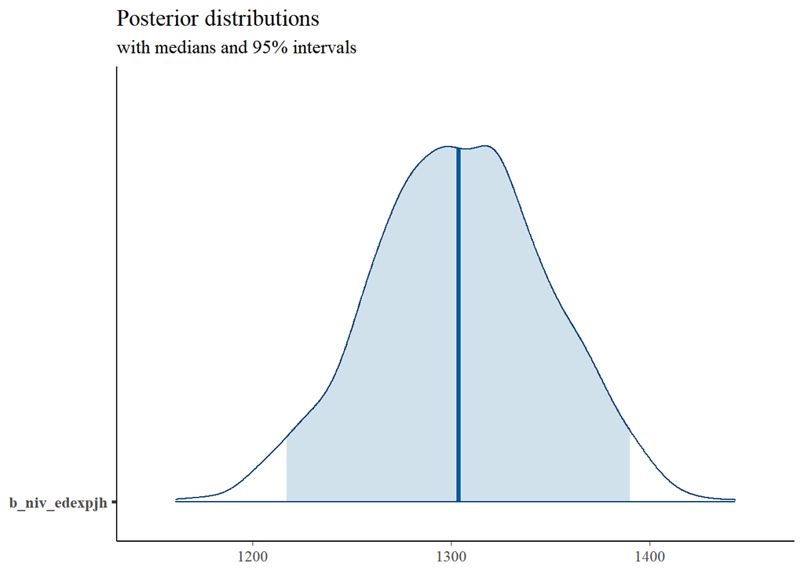

```r
library(ggplot2)
plot_title <- ggtitle("Posterior distributions",
                      "with medians and 95% intervals")
mcmc_areas(M1,
           pars = c("b_niv_edexpjh"),
           prob = 0.95) + plot_title
```

## Qué pasa ante cambios en el modelo?

El tamaño de localidad tiene a estar correlacionado con el nivel educativo entonces sería correcto ajustar el modelo incluyendo esta variable. El tamaño de localidad es, sin embargo, una variable nominal. Tenemos varias formas de incluir esta variable (crear variables binarias o utilizar la función de factor)

```r
M2<-brm(ictpc ~ 1 + niv_edexpjh + tamhogesc + factor(tam_loc), family="gaussian", iter=1000,
        prior = c(set_prior("normal(0,10000)", class = "b")),
        chains=4, cores=4,  threads = threading(14, grainsize = 100),backend = "cmdstanr", data=D)
```

```
## Running MCMC with 4 parallel chains, with 14 thread(s) per chain...
##
## Chain 1 Iteration:   1 / 1000 [  0%]  (Warmup)
## Chain 2 Iteration:   1 / 1000 [  0%]  (Warmup)
## Chain 3 Iteration:   1 / 1000 [  0%]  (Warmup)
## Chain 4 Iteration:   1 / 1000 [  0%]  (Warmup)
## Chain 4 Iteration: 100 / 1000 [ 10%]  (Warmup)
## Chain 3 Iteration: 100 / 1000 [ 10%]  (Warmup)
## Chain 2 Iteration: 100 / 1000 [ 10%]  (Warmup)
## Chain 1 Iteration: 100 / 1000 [ 10%]  (Warmup)
## Chain 2 Iteration: 200 / 1000 [ 20%]  (Warmup)
## Chain 4 Iteration: 200 / 1000 [ 20%]  (Warmup)
## Chain 2 Iteration: 300 / 1000 [ 30%]  (Warmup)
## Chain 2 Iteration: 400 / 1000 [ 40%]  (Warmup)
## Chain 2 Iteration: 500 / 1000 [ 50%]  (Warmup)
## Chain 2 Iteration: 501 / 1000 [ 50%]  (Sampling)
## Chain 4 Iteration: 300 / 1000 [ 30%]  (Warmup)
## Chain 1 Iteration: 200 / 1000 [ 20%]  (Warmup)
## Chain 2 Iteration: 600 / 1000 [ 60%]  (Sampling)
## Chain 4 Iteration: 400 / 1000 [ 40%]  (Warmup)
## Chain 2 Iteration: 700 / 1000 [ 70%]  (Sampling)
## Chain 3 Iteration: 200 / 1000 [ 20%]  (Warmup)
## Chain 4 Iteration: 500 / 1000 [ 50%]  (Warmup)
## Chain 4 Iteration: 501 / 1000 [ 50%]  (Sampling)
## Chain 1 Iteration: 300 / 1000 [ 30%]  (Warmup)
## Chain 2 Iteration: 800 / 1000 [ 80%]  (Sampling)
## Chain 4 Iteration: 600 / 1000 [ 60%]  (Sampling)
## Chain 1 Iteration: 400 / 1000 [ 40%]  (Warmup)
## Chain 3 Iteration: 300 / 1000 [ 30%]  (Warmup)
## Chain 4 Iteration: 700 / 1000 [ 70%]  (Sampling)
## Chain 1 Iteration: 500 / 1000 [ 50%]  (Warmup)
## Chain 1 Iteration: 501 / 1000 [ 50%]  (Sampling)
## Chain 2 Iteration: 900 / 1000 [ 90%]  (Sampling)
## Chain 4 Iteration: 800 / 1000 [ 80%]  (Sampling)
## Chain 2 Iteration: 1000 / 1000 [100%]  (Sampling)
## Chain 3 Iteration: 400 / 1000 [ 40%]  (Warmup)
## Chain 4 Iteration: 900 / 1000 [ 90%]  (Sampling)
## Chain 2 finished in 12.7 seconds.
## Chain 1 Iteration: 600 / 1000 [ 60%]  (Sampling)
## Chain 3 Iteration: 500 / 1000 [ 50%]  (Warmup)
## Chain 3 Iteration: 501 / 1000 [ 50%]  (Sampling)
## Chain 1 Iteration: 700 / 1000 [ 70%]  (Sampling)
## Chain 3 Iteration: 600 / 1000 [ 60%]  (Sampling)
## Chain 4 Iteration: 1000 / 1000 [100%]  (Sampling)
## Chain 4 finished in 12.9 seconds.
## Chain 1 Iteration: 800 / 1000 [ 80%]  (Sampling)
## Chain 3 Iteration: 700 / 1000 [ 70%]  (Sampling)
## Chain 1 Iteration: 900 / 1000 [ 90%]  (Sampling)
## Chain 3 Iteration: 800 / 1000 [ 80%]  (Sampling)
## Chain 1 Iteration: 1000 / 1000 [100%]  (Sampling)
## Chain 3 Iteration: 900 / 1000 [ 90%]  (Sampling)
## Chain 1 finished in 13.3 seconds.
## Chain 3 Iteration: 1000 / 1000 [100%]  (Sampling)
## Chain 3 finished in 13.4 seconds.
##
## All 4 chains finished successfully.
## Mean chain execution time: 13.1 seconds.
## Total execution time: 13.5 seconds.
```

```r
summary(M2)
```

```
##  Family: gaussian
##   Links: mu = identity; sigma = identity
## Formula: ictpc ~ 1 + niv_edexpjh + tamhogesc + factor(tam_loc)
##    Data: D (Number of observations: 20000)
##   Draws: 4 chains, each with iter = 1000; warmup = 500; thin = 1;
##          total post-warmup draws = 2000
##
## Population-Level Effects:
##                Estimate Est.Error l-95% CI u-95% CI Rhat Bulk_ESS Tail_ESS
## Intercept       4513.52    200.17  4142.95  4918.81 1.00     2098     1327
## niv_edexpjh     1141.62     48.56  1045.54  1232.26 1.00     2413     1602
## tamhogesc       -388.82     32.37  -452.25  -325.56 1.00     2582     1392
## factortam_loc2  -856.66    180.55 -1216.95  -500.86 1.00     2224     1456
## factortam_loc3 -1286.63    172.30 -1622.18  -939.82 1.00     2177     1721
## factortam_loc4 -1440.35    137.79 -1699.74 -1181.07 1.00     1979     1604
##
## Family Specific Parameters:
##       Estimate Est.Error l-95% CI u-95% CI Rhat Bulk_ESS Tail_ESS
## sigma  7576.85     37.08  7505.60  7649.00 1.00     2665     1659
##
## Draws were sampled using sample(hmc). For each parameter, Bulk_ESS
## and Tail_ESS are effective sample size measures, and Rhat is the potential
## scale reduction factor on split chains (at convergence, Rhat = 1).
```

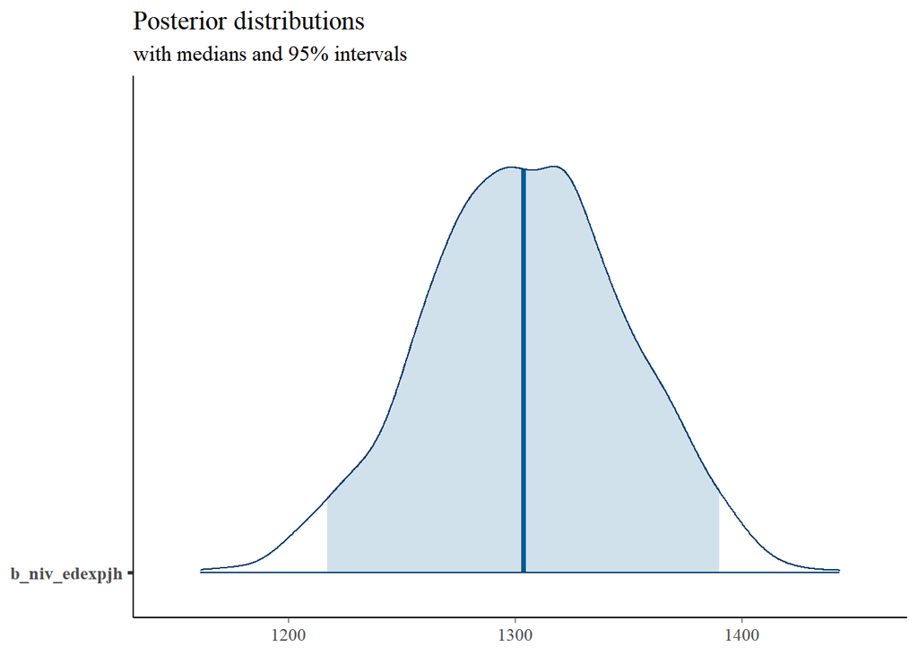

```r
plot_title <- ggtitle("Posterior distributions",
                      "with medians and 95% intervals")
mcmc_areas(M1,
           pars = c("b_niv_edexpjh"),
           prob = 0.95) + plot_title
```

Voy a comparar ambas distribuciones posteriores para ver si el efecto es distinto entre un modelo y otro.

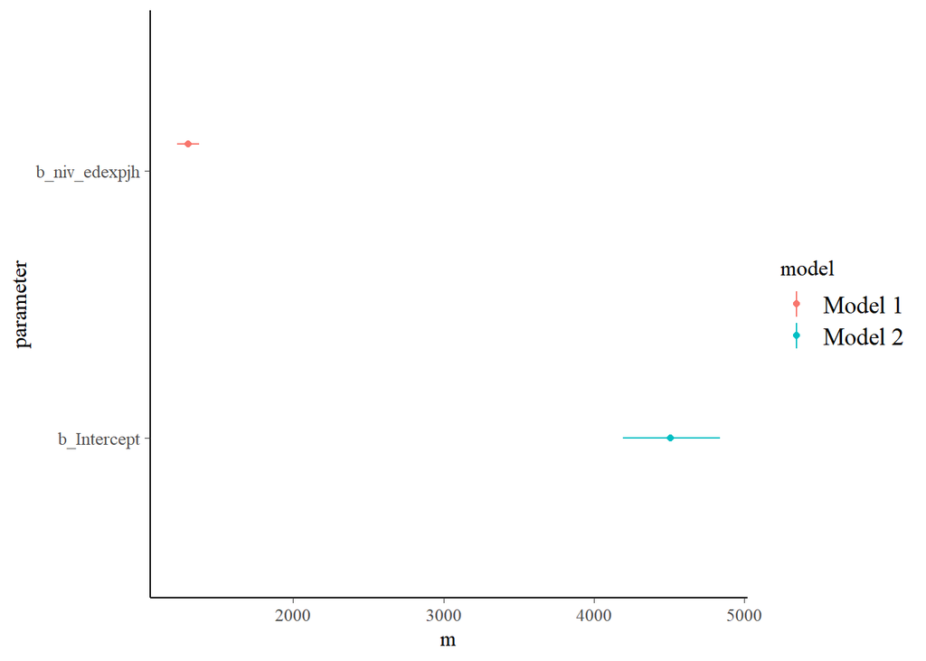

```r
combined <- rbind(mcmc_intervals_data(M1), mcmc_intervals_data(M2))
combined <- combined[c(2,7),]
combined$model <-c("Model 1", "Model 2")

# make the plot using ggplot
theme_set(bayesplot::theme_default())
pos <- position_nudge(y = ifelse(combined$model == "Model 2", 0, 0.1))
ggplot(combined, aes(x = m, y = parameter, color = model)) +
  geom_point(position = pos) +
  geom_linerange(aes(xmin = ll, xmax = hh), position = pos)
```

Efectivamente si incluyo el tamaño de localidad los resultados cambian. Ahora que pasa si me dicen en mi examen: Ya pero por lo menos ajusta tambien por entidad federativa!

```r
M3<-brm(ictpc ~ 1 + niv_edexpjh + tamhogesc + factor(tam_loc) + factor(ent),
        prior = c(set_prior("normal(0,10000)", class = "b")),
        family="gaussian", chains=4, cores=4, iter=1000,  threads = threading(14, grainsize = 100),backend = "cmdstanr", data=D)
```

```
## Running MCMC with 4 parallel chains, with 14 thread(s) per chain...
##
## Chain 1 Iteration:   1 / 1000 [  0%]  (Warmup)
## Chain 2 Iteration:   1 / 1000 [  0%]  (Warmup)
## Chain 3 Iteration:   1 / 1000 [  0%]  (Warmup)
## Chain 4 Iteration:   1 / 1000 [  0%]  (Warmup)
## Chain 2 Iteration: 100 / 1000 [ 10%]  (Warmup)
## Chain 4 Iteration: 100 / 1000 [ 10%]  (Warmup)
## Chain 1 Iteration: 100 / 1000 [ 10%]  (Warmup)
## Chain 3 Iteration: 100 / 1000 [ 10%]  (Warmup)
## Chain 2 Iteration: 200 / 1000 [ 20%]  (Warmup)
## Chain 4 Iteration: 200 / 1000 [ 20%]  (Warmup)
## Chain 1 Iteration: 200 / 1000 [ 20%]  (Warmup)
## Chain 2 Iteration: 300 / 1000 [ 30%]  (Warmup)
## Chain 4 Iteration: 300 / 1000 [ 30%]  (Warmup)
## Chain 2 Iteration: 400 / 1000 [ 40%]  (Warmup)
## Chain 4 Iteration: 400 / 1000 [ 40%]  (Warmup)
## Chain 2 Iteration: 500 / 1000 [ 50%]  (Warmup)
## Chain 3 Iteration: 200 / 1000 [ 20%]  (Warmup)
## Chain 2 Iteration: 501 / 1000 [ 50%]  (Sampling)
## Chain 4 Iteration: 500 / 1000 [ 50%]  (Warmup)
## Chain 1 Iteration: 300 / 1000 [ 30%]  (Warmup)
## Chain 2 Iteration: 600 / 1000 [ 60%]  (Sampling)
## Chain 4 Iteration: 501 / 1000 [ 50%]  (Sampling)
## Chain 4 Iteration: 600 / 1000 [ 60%]  (Sampling)
## Chain 2 Iteration: 700 / 1000 [ 70%]  (Sampling)
## Chain 1 Iteration: 400 / 1000 [ 40%]  (Warmup)
## Chain 4 Iteration: 700 / 1000 [ 70%]  (Sampling)
## Chain 2 Iteration: 800 / 1000 [ 80%]  (Sampling)
## Chain 3 Iteration: 300 / 1000 [ 30%]  (Warmup)
## Chain 1 Iteration: 500 / 1000 [ 50%]  (Warmup)
## Chain 2 Iteration: 900 / 1000 [ 90%]  (Sampling)
## Chain 4 Iteration: 800 / 1000 [ 80%]  (Sampling)
## Chain 1 Iteration: 501 / 1000 [ 50%]  (Sampling)
## Chain 2 Iteration: 1000 / 1000 [100%]  (Sampling)
## Chain 3 Iteration: 400 / 1000 [ 40%]  (Warmup)
## Chain 4 Iteration: 900 / 1000 [ 90%]  (Sampling)
## Chain 2 finished in 29.8 seconds.
## Chain 1 Iteration: 600 / 1000 [ 60%]  (Sampling)
## Chain 4 Iteration: 1000 / 1000 [100%]  (Sampling)
## Chain 4 finished in 30.0 seconds.
## Chain 1 Iteration: 700 / 1000 [ 70%]  (Sampling)
## Chain 3 Iteration: 500 / 1000 [ 50%]  (Warmup)
## Chain 3 Iteration: 501 / 1000 [ 50%]  (Sampling)
## Chain 3 Iteration: 600 / 1000 [ 60%]  (Sampling)
## Chain 1 Iteration: 800 / 1000 [ 80%]  (Sampling)
## Chain 3 Iteration: 700 / 1000 [ 70%]  (Sampling)
## Chain 1 Iteration: 900 / 1000 [ 90%]  (Sampling)
## Chain 3 Iteration: 800 / 1000 [ 80%]  (Sampling)
## Chain 1 Iteration: 1000 / 1000 [100%]  (Sampling)
## Chain 3 Iteration: 900 / 1000 [ 90%]  (Sampling)
## Chain 1 finished in 30.8 seconds.
## Chain 3 Iteration: 1000 / 1000 [100%]  (Sampling)
## Chain 3 finished in 30.9 seconds.
##
## All 4 chains finished successfully.
## Mean chain execution time: 30.4 seconds.
## Total execution time: 31.1 seconds.
```

```r
summary(M3)
```

```
##  Family: gaussian
##   Links: mu = identity; sigma = identity
## Formula: ictpc ~ 1 + niv_edexpjh + tamhogesc + factor(tam_loc) + factor(ent)
##    Data: D (Number of observations: 20000)
##   Draws: 4 chains, each with iter = 1000; warmup = 500; thin = 1;
##          total post-warmup draws = 2000
##
## Population-Level Effects:
##                Estimate Est.Error l-95% CI u-95% CI Rhat Bulk_ESS Tail_ESS
## Intercept       4895.57    334.49  4246.52  5571.17 1.02      259      448
## niv_edexpjh     1100.03     44.72  1009.70  1185.94 1.00     1587     1603
## tamhogesc       -376.18     31.63  -440.62  -312.34 1.00     1826     1544
## factortam_loc2  -673.46    181.06 -1033.79  -331.34 1.00     1208     1249
## factortam_loc3  -955.63    184.23 -1313.78  -601.33 1.00     1324     1421
## factortam_loc4 -1218.73    136.78 -1477.62  -949.95 1.00     1176     1595
## factorent2       123.91    381.77  -635.06   877.80 1.01      298      704
## factorent3      2311.45    439.29  1437.87  3155.96 1.01      372      803
## factorent4      -448.55    440.96 -1304.45   414.02 1.01      366      969
## factorent5       -89.36    384.24  -805.78   667.47 1.01      309      778
## factorent6      -504.73    397.49 -1267.84   262.77 1.01      320      853
## factorent7     -1856.27    437.94 -2708.15  -994.92 1.01      406      853
## factorent8      -293.83    378.83 -1047.41   453.92 1.01      310      766
## factorent9      -345.39    438.00 -1208.49   534.66 1.01      335      738
## factorent10    -1120.57    406.16 -1923.22  -320.65 1.01      339      593
## factorent11     -731.26    393.99 -1500.57    49.17 1.01      286      680
## factorent12    -1407.38    437.67 -2205.00  -496.56 1.01      342      961
## factorent13     -477.04    443.46 -1339.66   387.65 1.01      391      756
## factorent14      425.07    414.69  -408.42  1211.21 1.01      355      716
## factorent15    -1198.59    385.52 -1936.78  -432.72 1.01      303      891
## factorent16     -486.76    439.03 -1313.71   391.82 1.01      372      951
## factorent17    -1431.56    436.83 -2296.88  -566.12 1.01      368      798
## factorent18      155.87    445.79  -738.89  1034.22 1.01      378      789
## factorent19      743.85    384.16   -11.46  1492.32 1.01      331      815
## factorent20    -1543.16    422.83 -2375.70  -723.94 1.01      368      813
## factorent21    -1603.62    442.02 -2456.60  -742.92 1.01      355      780
## factorent22     -275.21    385.57 -1017.31   476.03 1.01      323      859
## factorent23      438.30    443.59  -460.88  1333.44 1.01      419      877
## factorent24     -965.85    414.42 -1780.68  -184.56 1.01      344      737
## factorent25      355.02    391.46  -403.77  1105.94 1.01      325      742
## factorent26     -155.73    425.95  -980.43   653.17 1.01      372      922
## factorent27    -1602.10    455.69 -2505.20  -716.42 1.01      367      931
## factorent28    -1052.10    443.34 -1902.52  -163.84 1.01      431      951
## factorent29    -1305.98    443.67 -2172.24  -440.51 1.01      395      842
## factorent30    -1631.09    427.02 -2475.37  -810.06 1.01      364      862
## factorent31     -564.51    410.12 -1366.46   209.99 1.01      319      744
## factorent32     -965.34    413.56 -1807.32  -184.11 1.01      335      684
##
## Family Specific Parameters:
##       Estimate Est.Error l-95% CI u-95% CI Rhat Bulk_ESS Tail_ESS
## sigma  7537.80     38.21  7466.37  7611.36 1.00     3570     1482
##
## Draws were sampled using sample(hmc). For each parameter, Bulk_ESS
## and Tail_ESS are effective sample size measures, and Rhat is the potential
## scale reduction factor on split chains (at convergence, Rhat = 1).
```

Uh! esas posteriores no se ven muy sanas. Siempre muchas binarias son un problema. Antes de interpretar tengo que ajustar de alguna manera la estimación (priors o más cadenas)

```r
M3<-brm(ictpc ~ 1 + niv_edexpjh + tamhogesc + factor(tam_loc) + factor(ent),
        prior = c(set_prior("normal(0,10000)", class = "b")),
        family="gaussian", chains=4, cores=4, iter=1000,  threads = threading(14, grainsize = 100),backend = "cmdstanr", data=D)
```

```
## Running MCMC with 4 parallel chains, with 14 thread(s) per chain...
##
## Chain 1 Iteration:   1 / 1000 [  0%]  (Warmup)
## Chain 2 Iteration:   1 / 1000 [  0%]  (Warmup)
## Chain 3 Iteration:   1 / 1000 [  0%]  (Warmup)
## Chain 4 Iteration:   1 / 1000 [  0%]  (Warmup)
## Chain 2 Iteration: 100 / 1000 [ 10%]  (Warmup)
## Chain 4 Iteration: 100 / 1000 [ 10%]  (Warmup)
## Chain 3 Iteration: 100 / 1000 [ 10%]  (Warmup)
## Chain 1 Iteration: 100 / 1000 [ 10%]  (Warmup)
## Chain 2 Iteration: 200 / 1000 [ 20%]  (Warmup)
## Chain 3 Iteration: 200 / 1000 [ 20%]  (Warmup)
## Chain 4 Iteration: 200 / 1000 [ 20%]  (Warmup)
## Chain 2 Iteration: 300 / 1000 [ 30%]  (Warmup)
## Chain 2 Iteration: 400 / 1000 [ 40%]  (Warmup)
## Chain 3 Iteration: 300 / 1000 [ 30%]  (Warmup)
## Chain 2 Iteration: 500 / 1000 [ 50%]  (Warmup)
## Chain 4 Iteration: 300 / 1000 [ 30%]  (Warmup)
## Chain 2 Iteration: 501 / 1000 [ 50%]  (Sampling)
## Chain 3 Iteration: 400 / 1000 [ 40%]  (Warmup)
## Chain 2 Iteration: 600 / 1000 [ 60%]  (Sampling)
## Chain 4 Iteration: 400 / 1000 [ 40%]  (Warmup)
## Chain 2 Iteration: 700 / 1000 [ 70%]  (Sampling)
## Chain 3 Iteration: 500 / 1000 [ 50%]  (Warmup)
## Chain 3 Iteration: 501 / 1000 [ 50%]  (Sampling)
## Chain 4 Iteration: 500 / 1000 [ 50%]  (Warmup)
## Chain 3 Iteration: 600 / 1000 [ 60%]  (Sampling)
## Chain 4 Iteration: 501 / 1000 [ 50%]  (Sampling)
## Chain 2 Iteration: 800 / 1000 [ 80%]  (Sampling)
## Chain 3 Iteration: 700 / 1000 [ 70%]  (Sampling)
## Chain 4 Iteration: 600 / 1000 [ 60%]  (Sampling)
## Chain 2 Iteration: 900 / 1000 [ 90%]  (Sampling)
## Chain 4 Iteration: 700 / 1000 [ 70%]  (Sampling)
## Chain 3 Iteration: 800 / 1000 [ 80%]  (Sampling)
## Chain 2 Iteration: 1000 / 1000 [100%]  (Sampling)
## Chain 4 Iteration: 800 / 1000 [ 80%]  (Sampling)
## Chain 2 finished in 30.4 seconds.
## Chain 1 Iteration: 200 / 1000 [ 20%]  (Warmup)
## Chain 3 Iteration: 900 / 1000 [ 90%]  (Sampling)
## Chain 4 Iteration: 900 / 1000 [ 90%]  (Sampling)
## Chain 3 Iteration: 1000 / 1000 [100%]  (Sampling)
## Chain 3 finished in 30.7 seconds.
## Chain 4 Iteration: 1000 / 1000 [100%]  (Sampling)
## Chain 4 finished in 30.8 seconds.
## Chain 1 Iteration: 300 / 1000 [ 30%]  (Warmup)
## Chain 1 Iteration: 400 / 1000 [ 40%]  (Warmup)
## Chain 1 Iteration: 500 / 1000 [ 50%]  (Warmup)
## Chain 1 Iteration: 501 / 1000 [ 50%]  (Sampling)
## Chain 1 Iteration: 600 / 1000 [ 60%]  (Sampling)
## Chain 1 Iteration: 700 / 1000 [ 70%]  (Sampling)
## Chain 1 Iteration: 800 / 1000 [ 80%]  (Sampling)
## Chain 1 Iteration: 900 / 1000 [ 90%]  (Sampling)
## Chain 1 Iteration: 1000 / 1000 [100%]  (Sampling)
## Chain 1 finished in 32.4 seconds.
##
## All 4 chains finished successfully.
## Mean chain execution time: 31.1 seconds.
## Total execution time: 32.6 seconds.
```

```r
summary(M3)
```

```
##  Family: gaussian
##   Links: mu = identity; sigma = identity
## Formula: ictpc ~ 1 + niv_edexpjh + tamhogesc + factor(tam_loc) + factor(ent)
##    Data: D (Number of observations: 20000)
##   Draws: 4 chains, each with iter = 1000; warmup = 500; thin = 1;
##          total post-warmup draws = 2000
##
## Population-Level Effects:
##                Estimate Est.Error l-95% CI u-95% CI Rhat Bulk_ESS Tail_ESS
## Intercept       4885.00    340.37  4229.13  5549.15 1.02      268      431
## niv_edexpjh     1101.97     45.03  1016.05  1188.08 1.00     1398     1416
## tamhogesc       -374.69     32.54  -437.97  -313.43 1.00     1400     1410
## factortam_loc2  -675.82    178.35 -1041.95  -340.36 1.00     1481     1441
## factortam_loc3  -954.28    186.74 -1315.83  -592.27 1.00     1052     1361
## factortam_loc4 -1216.45    138.39 -1478.59  -934.68 1.00     1192     1309
## factorent2       110.56    375.55  -617.93   879.83 1.01      317      643
## factorent3      2318.95    431.87  1456.02  3155.22 1.01      336      762
## factorent4      -451.16    430.07 -1268.43   360.47 1.01      363      765
## factorent5       -98.14    390.31  -870.55   669.23 1.01      329      572
## factorent6      -506.97    398.72 -1305.45   283.05 1.01      315      700
## factorent7     -1867.14    437.61 -2762.25 -1034.55 1.01      371      776
## factorent8      -295.92    370.69 -1001.38   430.40 1.01      295      537
## factorent9      -358.05    412.56 -1152.61   456.80 1.01      361      553
## factorent10    -1117.39    407.20 -1890.67  -321.94 1.01      326      633
## factorent11     -738.92    388.56 -1461.28    18.31 1.01      314      742
## factorent12    -1408.53    438.77 -2250.55  -552.35 1.01      361      893
## factorent13     -469.78    441.83 -1304.98   372.96 1.01      380      798
## factorent14      421.89    421.08  -409.65  1232.54 1.01      348      762
## factorent15    -1214.76    385.61 -1959.41  -473.93 1.01      332      636
## factorent16     -484.30    439.51 -1377.31   343.89 1.01      394      922
## factorent17    -1423.50    441.49 -2317.38  -571.41 1.01      384      759
## factorent18      146.03    451.80  -718.04  1048.93 1.01      368      572
## factorent19      743.00    390.54   -11.95  1513.37 1.01      336      624
## factorent20    -1530.01    430.68 -2382.68  -721.52 1.01      347      582
## factorent21    -1598.23    428.24 -2433.88  -735.58 1.01      382      621
## factorent22     -285.52    384.95 -1044.02   501.14 1.01      314      555
## factorent23      442.72    455.40  -476.00  1303.70 1.01      424      803
## factorent24     -962.91    417.22 -1796.31  -163.72 1.01      366      699
## factorent25      347.62    394.33  -411.07  1146.67 1.01      342      689
## factorent26     -156.58    437.90 -1043.52   719.43 1.01      409      760
## factorent27    -1604.72    432.96 -2448.36  -771.94 1.01      363      771
## factorent28    -1049.74    455.37 -1955.08  -150.20 1.01      417      868
## factorent29    -1318.15    435.11 -2173.39  -468.79 1.01      335      778
## factorent30    -1637.17    407.50 -2449.73  -868.76 1.01      335      760
## factorent31     -565.09    393.79 -1353.74   197.82 1.01      323      645
## factorent32     -956.85    418.31 -1755.76  -144.48 1.01      349      876
##
## Family Specific Parameters:
##       Estimate Est.Error l-95% CI u-95% CI Rhat Bulk_ESS Tail_ESS
## sigma  7539.13     37.34  7466.89  7611.84 1.00     4333     1539
##
## Draws were sampled using sample(hmc). For each parameter, Bulk_ESS
## and Tail_ESS are effective sample size measures, and Rhat is the potential
## scale reduction factor on split chains (at convergence, Rhat = 1).
```

Ahora comparo los tres modelos. Concluyo que mi conclusión se sostiene.

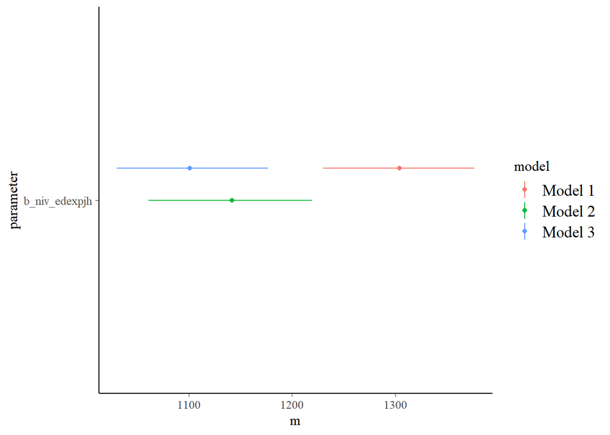

```r
combined <- rbind(mcmc_intervals_data(M1), mcmc_intervals_data(M2),  mcmc_intervals_data(M3))
combined <- subset(combined, parameter=="b_niv_edexpjh")
combined$model <-c("Model 1", "Model 2", "Model 3")

# make the plot using ggplot
theme_set(bayesplot::theme_default())
pos <- position_nudge(y = ifelse(combined$model == "Model 2", 0, 0.1))
ggplot(combined, aes(x = m, y = parameter, color = model)) +
  geom_point(position = pos) +
  geom_linerange(aes(xmin = ll, xmax = hh), position = pos)
```

## Si pero… qué tal si el efecto no es proporcional por nivel educativo. Tengo 5 Niveles.

```r
M4<-brm(ictpc ~ 1 + factor(niv_edexpjh) + tamhogesc + factor(tam_loc) + factor(ent),
        prior = c(set_prior("normal(0,10000)", class = "b")),
        family="gaussian", chains=4, cores=4, iter=1500,  threads = threading(8, grainsize = 100),backend = "cmdstanr", data=D)
```

```
## Running MCMC with 4 parallel chains, with 8 thread(s) per chain...
##
## Chain 1 Iteration:    1 / 1500 [  0%]  (Warmup)
## Chain 2 Iteration:    1 / 1500 [  0%]  (Warmup)
## Chain 3 Iteration:    1 / 1500 [  0%]  (Warmup)
## Chain 4 Iteration:    1 / 1500 [  0%]  (Warmup)
## Chain 1 Iteration:  100 / 1500 [  6%]  (Warmup)
## Chain 4 Iteration:  100 / 1500 [  6%]  (Warmup)
## Chain 2 Iteration:  100 / 1500 [  6%]  (Warmup)
## Chain 3 Iteration:  100 / 1500 [  6%]  (Warmup)
## Chain 1 Iteration:  200 / 1500 [ 13%]  (Warmup)
## Chain 4 Iteration:  200 / 1500 [ 13%]  (Warmup)
## Chain 1 Iteration:  300 / 1500 [ 20%]  (Warmup)
## Chain 1 Iteration:  400 / 1500 [ 26%]  (Warmup)
## Chain 1 Iteration:  500 / 1500 [ 33%]  (Warmup)
## Chain 1 Iteration:  600 / 1500 [ 40%]  (Warmup)
## Chain 4 Iteration:  300 / 1500 [ 20%]  (Warmup)
## Chain 3 Iteration:  200 / 1500 [ 13%]  (Warmup)
## Chain 1 Iteration:  700 / 1500 [ 46%]  (Warmup)
## Chain 4 Iteration:  400 / 1500 [ 26%]  (Warmup)
## Chain 1 Iteration:  751 / 1500 [ 50%]  (Sampling)
## Chain 4 Iteration:  500 / 1500 [ 33%]  (Warmup)
## Chain 1 Iteration:  850 / 1500 [ 56%]  (Sampling)
## Chain 4 Iteration:  600 / 1500 [ 40%]  (Warmup)
## Chain 1 Iteration:  950 / 1500 [ 63%]  (Sampling)
## Chain 4 Iteration:  700 / 1500 [ 46%]  (Warmup)
## Chain 1 Iteration: 1050 / 1500 [ 70%]  (Sampling)
## Chain 3 Iteration:  300 / 1500 [ 20%]  (Warmup)
## Chain 4 Iteration:  751 / 1500 [ 50%]  (Sampling)
## Chain 1 Iteration: 1150 / 1500 [ 76%]  (Sampling)
## Chain 3 Iteration:  400 / 1500 [ 26%]  (Warmup)
## Chain 4 Iteration:  850 / 1500 [ 56%]  (Sampling)
## Chain 1 Iteration: 1250 / 1500 [ 83%]  (Sampling)
## Chain 3 Iteration:  500 / 1500 [ 33%]  (Warmup)
## Chain 4 Iteration:  950 / 1500 [ 63%]  (Sampling)
## Chain 1 Iteration: 1350 / 1500 [ 90%]  (Sampling)
## Chain 3 Iteration:  600 / 1500 [ 40%]  (Warmup)
## Chain 4 Iteration: 1050 / 1500 [ 70%]  (Sampling)
## Chain 1 Iteration: 1450 / 1500 [ 96%]  (Sampling)
## Chain 1 Iteration: 1500 / 1500 [100%]  (Sampling)
```

[output cut: 23 more lines]

```
## Chain 3 Iteration: 1500 / 1500 [100%]  (Sampling)
## Chain 3 finished in 28.1 seconds.
## Chain 2 Iteration:  850 / 1500 [ 56%]  (Sampling)
## Chain 2 Iteration:  950 / 1500 [ 63%]  (Sampling)
## Chain 2 Iteration: 1050 / 1500 [ 70%]  (Sampling)
## Chain 2 Iteration: 1150 / 1500 [ 76%]  (Sampling)
## Chain 2 Iteration: 1250 / 1500 [ 83%]  (Sampling)
## Chain 2 Iteration: 1350 / 1500 [ 90%]  (Sampling)
## Chain 2 Iteration: 1450 / 1500 [ 96%]  (Sampling)
## Chain 2 Iteration: 1500 / 1500 [100%]  (Sampling)
## Chain 2 finished in 29.1 seconds.
##
## All 4 chains finished successfully.
## Mean chain execution time: 27.8 seconds.
## Total execution time: 29.3 seconds.
```

```r
summary(M4)
```

```
##  Family: gaussian
##   Links: mu = identity; sigma = identity
## Formula: ictpc ~ 1 + factor(niv_edexpjh) + tamhogesc + factor(tam_loc) + factor(ent)
##    Data: D (Number of observations: 20000)
##   Draws: 4 chains, each with iter = 1500; warmup = 750; thin = 1;
##          total post-warmup draws = 3000
##
## Population-Level Effects:
##                    Estimate Est.Error l-95% CI u-95% CI Rhat Bulk_ESS Tail_ESS
## Intercept           5616.15    363.60  4888.52  6343.72 1.02      232      665
## factorniv_edexpjh1   176.97    155.25  -127.03   482.14 1.00     1515     2042
## factorniv_edexpjh2   415.40    149.96   114.52   703.25 1.00     1453     2010
## factorniv_edexpjh3  2004.17    189.13  1624.25  2375.03 1.00     1619     1948
## factorniv_edexpjh4  5843.04    211.39  5417.50  6249.88 1.00     1643     1897
## tamhogesc           -361.85     31.65  -421.85  -299.33 1.00     2763     2118
## factortam_loc2      -513.41    181.33  -863.36  -151.90 1.00     1909     2122
## factortam_loc3      -768.72    184.80 -1118.19  -398.66 1.00     1729     1997
## factortam_loc4     -1076.27    135.58 -1338.18  -811.55 1.00     1669     2263
## factorent2            88.52    394.82  -668.56   889.23 1.01      282      782
## factorent3          2321.69    435.14  1473.84  3178.31 1.01      351      883
## factorent4          -554.12    461.26 -1472.05   363.07 1.01      345     1088
## factorent5            -0.68    396.87  -784.51   783.93 1.02      279      965
## factorent6          -621.38    407.67 -1432.39   173.67 1.02      283      830
## factorent7         -2104.92    447.00 -2991.79 -1266.35 1.01      384      849
## factorent8          -394.07    401.47 -1183.80   404.79 1.02      278      646
## factorent9          -361.48    435.06 -1202.76   493.56 1.01      348      922
## factorent10        -1112.73    430.12 -1968.10  -242.99 1.01      314      996
## factorent11         -868.20    402.30 -1686.56   -78.16 1.02      278      735
## factorent12        -1657.56    444.56 -2530.93  -768.70 1.01      339      710
## factorent13         -485.61    450.93 -1395.66   397.33 1.01      353      884
## factorent14          203.02    438.44  -693.96  1049.01 1.01      330      812
## factorent15        -1143.55    399.91 -1915.20  -365.59 1.01      275      539
## factorent16         -650.98    453.40 -1497.89   260.69 1.01      364      980
## factorent17        -1445.83    458.12 -2356.44  -575.01 1.01      374      954
## factorent18           72.12    464.48  -829.49   977.21 1.01      324      645
## factorent19          778.36    408.73   -23.08  1575.48 1.01      279      835
## factorent20        -1855.69    450.68 -2723.31  -938.50 1.01      334      956
## factorent21        -1725.25    447.89 -2590.92  -849.26 1.01      323     1065
## factorent22         -278.95    394.69 -1064.45   494.50 1.02      277      716
## factorent23          444.30    470.82  -473.14  1364.78 1.01      376     1104
## factorent24        -1040.83    436.26 -1906.36  -204.79 1.01      336      993
## factorent25           91.00    403.61  -686.03   876.83 1.02      272      712
## factorent26         -196.32    453.54 -1089.14   680.83 1.01      367      882
## factorent27        -1703.07    456.71 -2588.09  -798.58 1.01      329      947
## factorent28        -1055.35    467.90 -1979.34  -128.42 1.01      386      644
## factorent29        -1366.51    437.90 -2233.35  -526.63 1.01      288      795
## factorent30        -1911.71    434.81 -2779.46 -1069.83 1.01      331      896
## factorent31         -717.44    417.57 -1512.53   106.21 1.01      290      564
## factorent32        -1003.72    424.66 -1832.39  -173.94 1.01      329      766
##
## Family Specific Parameters:
##       Estimate Est.Error l-95% CI u-95% CI Rhat Bulk_ESS Tail_ESS
## sigma  7475.23     37.01  7403.73  7547.50 1.00     4402     2012
##
## Draws were sampled using sample(hmc). For each parameter, Bulk_ESS
## and Tail_ESS are effective sample size measures, and Rhat is the potential
## scale reduction factor on split chains (at convergence, Rhat = 1).
```

Si uso la vía de comparar simplemente los coeficientes usando como referencia a las personas sin educación primaria, concluiría que el efecto no parece ser lineal.

**Es la única manera? Qué se les ocurre?**

```r
get_variables(M4)
```

```
##  [1] "b_Intercept"          "b_factorniv_edexpjh1" "b_factorniv_edexpjh2"
##  [4] "b_factorniv_edexpjh3" "b_factorniv_edexpjh4" "b_tamhogesc"
##  [7] "b_factortam_loc2"     "b_factortam_loc3"     "b_factortam_loc4"
## [10] "b_factorent2"         "b_factorent3"         "b_factorent4"
## [13] "b_factorent5"         "b_factorent6"         "b_factorent7"
## [16] "b_factorent8"         "b_factorent9"         "b_factorent10"
## [19] "b_factorent11"        "b_factorent12"        "b_factorent13"
## [22] "b_factorent14"        "b_factorent15"        "b_factorent16"
## [25] "b_factorent17"        "b_factorent18"        "b_factorent19"
## [28] "b_factorent20"        "b_factorent21"        "b_factorent22"
## [31] "b_factorent23"        "b_factorent24"        "b_factorent25"
## [34] "b_factorent26"        "b_factorent27"        "b_factorent28"
## [37] "b_factorent29"        "b_factorent30"        "b_factorent31"
## [40] "b_factorent32"        "sigma"                "lprior"
## [43] "lp__"                 "accept_stat__"        "treedepth__"
## [46] "stepsize__"           "divergent__"          "n_leapfrog__"
## [49] "energy__"
```

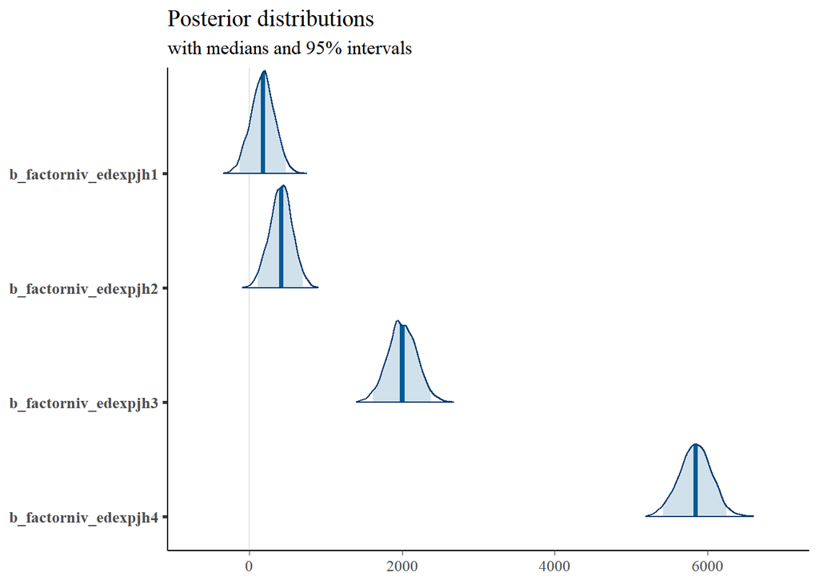

```r
plot_title <- ggtitle("Posterior distributions",
                      "with medians and 95% intervals")
mcmc_areas(M4,
           pars = c( "b_factorniv_edexpjh1", "b_factorniv_edexpjh2", "b_factorniv_edexpjh3", "b_factorniv_edexpjh4"),
           prob = 0.95) + plot_title
```

Para hacer cálculos de efectos marginales, es necesario trabajar con variables binarias. Esto porque vamos a usar el paquete `ggeffects()`.

```r
library(fastDummies)
D<-dummy_cols(D, select_columns = c("niv_edexpjh", "ent", "tam_loc"))
M4<-brm(ictpc ~ 1 + niv_edexpjh_1 + niv_edexpjh_2 + niv_edexpjh_3 + niv_edexpjh_4 + tamhogesc + ent_10 + ent_11 + ent_12  + ent_13 + ent_14 + ent_15 +          ent_16 + ent_17 + ent_18 + ent_19 + ent_2 + ent_20 + ent_21 +   ent_22   + ent_23 + ent_24  + ent_25 + ent_26  +  ent_27 +  ent_28 +  ent_29 +         ent_3  + ent_30  + ent_31 +   ent_32 + ent_4  +   ent_5  + ent_6 + ent_7 +   ent_8 + ent_9  + tam_loc_1 +  tam_loc_2 + tam_loc_3  +
tam_loc_4, family="gaussian", iter=1500, cores=2, chains=2,  threads = threading(8, grainsize = 100),backend = "cmdstanr", data=D, prior = c(set_prior("normal(0,1000)", class = "b")))
```

```
## Running MCMC with 2 parallel chains, with 8 thread(s) per chain...
##
## Chain 1 Iteration:    1 / 1500 [  0%]  (Warmup)
## Chain 2 Iteration:    1 / 1500 [  0%]  (Warmup)
## Chain 2 Iteration:  100 / 1500 [  6%]  (Warmup)
## Chain 1 Iteration:  100 / 1500 [  6%]  (Warmup)
## Chain 2 Iteration:  200 / 1500 [ 13%]  (Warmup)
## Chain 2 Iteration:  300 / 1500 [ 20%]  (Warmup)
## Chain 2 Iteration:  400 / 1500 [ 26%]  (Warmup)
## Chain 2 Iteration:  500 / 1500 [ 33%]  (Warmup)
## Chain 1 Iteration:  200 / 1500 [ 13%]  (Warmup)
## Chain 2 Iteration:  600 / 1500 [ 40%]  (Warmup)
## Chain 2 Iteration:  700 / 1500 [ 46%]  (Warmup)
## Chain 1 Iteration:  300 / 1500 [ 20%]  (Warmup)
## Chain 2 Iteration:  751 / 1500 [ 50%]  (Sampling)
## Chain 1 Iteration:  400 / 1500 [ 26%]  (Warmup)
## Chain 2 Iteration:  850 / 1500 [ 56%]  (Sampling)
## Chain 1 Iteration:  500 / 1500 [ 33%]  (Warmup)
## Chain 1 Iteration:  600 / 1500 [ 40%]  (Warmup)
## Chain 2 Iteration:  950 / 1500 [ 63%]  (Sampling)
## Chain 1 Iteration:  700 / 1500 [ 46%]  (Warmup)
## Chain 2 Iteration: 1050 / 1500 [ 70%]  (Sampling)
## Chain 1 Iteration:  751 / 1500 [ 50%]  (Sampling)
## Chain 1 Iteration:  850 / 1500 [ 56%]  (Sampling)
## Chain 2 Iteration: 1150 / 1500 [ 76%]  (Sampling)
## Chain 2 Iteration: 1250 / 1500 [ 83%]  (Sampling)
## Chain 1 Iteration:  950 / 1500 [ 63%]  (Sampling)
## Chain 2 Iteration: 1350 / 1500 [ 90%]  (Sampling)
## Chain 1 Iteration: 1050 / 1500 [ 70%]  (Sampling)
## Chain 1 Iteration: 1150 / 1500 [ 76%]  (Sampling)
## Chain 2 Iteration: 1450 / 1500 [ 96%]  (Sampling)
## Chain 2 Iteration: 1500 / 1500 [100%]  (Sampling)
## Chain 2 finished in 22.7 seconds.
## Chain 1 Iteration: 1250 / 1500 [ 83%]  (Sampling)
## Chain 1 Iteration: 1350 / 1500 [ 90%]  (Sampling)
## Chain 1 Iteration: 1450 / 1500 [ 96%]  (Sampling)
## Chain 1 Iteration: 1500 / 1500 [100%]  (Sampling)
## Chain 1 finished in 24.1 seconds.
##
## Both chains finished successfully.
## Mean chain execution time: 23.4 seconds.
## Total execution time: 24.3 seconds.
```

```r
summary(M4)
```

```
##  Family: gaussian
##   Links: mu = identity; sigma = identity
## Formula: ictpc ~ 1 + niv_edexpjh_1 + niv_edexpjh_2 + niv_edexpjh_3 + niv_edexpjh_4 + tamhogesc + ent_10 + ent_11 + ent_12 + ent_13 + ent_14 + ent_15 + ent_16 + ent_17 + ent_18 + ent_19 + ent_2 + ent_20 + ent_21 + ent_22 + ent_23 + ent_24 + ent_25 + ent_26 + ent_27 + ent_28 + ent_29 + ent_3 + ent_…
##    Data: D (Number of observations: 20000)
##   Draws: 2 chains, each with iter = 1500; warmup = 750; thin = 1;
##          total post-warmup draws = 1500
##
## Population-Level Effects:
##               Estimate Est.Error l-95% CI u-95% CI Rhat Bulk_ESS Tail_ESS
## Intercept      4670.62    547.76  3574.77  5729.46 1.00      739      675
## niv_edexpjh_1    81.08    158.92  -227.44   383.47 1.00     1590     1213
## niv_edexpjh_2   324.44    144.76    39.52   602.28 1.00     1604     1311
## niv_edexpjh_3  1867.00    189.07  1496.91  2235.31 1.00     1798     1093
## niv_edexpjh_4  5573.26    204.32  5187.20  5982.37 1.00     1671     1299
## tamhogesc      -364.03     31.56  -428.05  -301.80 1.00     3613     1025
## ent_10         -613.30    318.50 -1255.01     6.75 1.00     1278     1166
## ent_11         -402.33    295.82  -973.78   196.54 1.00     1092     1072
## ent_12        -1111.68    346.17 -1823.16  -435.18 1.00     1211      985
## ent_13          -32.60    355.75  -741.24   671.33 1.00     1307      932
## ent_14          584.93    328.70   -39.41  1251.64 1.00     1463      626
## ent_15         -655.63    301.48 -1234.06   -90.19 1.00      962     1025
## ent_16         -186.39    340.84  -828.82   486.06 1.00     1363     1304
## ent_17         -902.90    344.00 -1569.09  -214.77 1.00     1548      971
## ent_18          475.53    371.23  -280.60  1170.63 1.00     1570      960
## ent_19         1128.35    285.69   573.12  1681.00 1.00      958      937
## ent_2           495.60    284.76   -60.12  1049.31 1.00     1032     1112
## ent_20        -1285.48    335.13 -1998.78  -644.67 1.00     1399      991
## ent_21        -1146.91    357.27 -1856.40  -424.47 1.00     1300      838
## ent_22          170.25    278.65  -365.88   750.37 1.00      988      952
## ent_23          784.40    378.78    39.36  1531.47 1.00     1683      950
## ent_24         -547.68    333.87 -1204.05    94.35 1.00     1186     1038
## ent_25          514.91    314.95   -74.45  1176.87 1.00     1215      840
## ent_26          243.04    343.87  -434.19   958.75 1.00     1439     1077
## ent_27        -1110.95    345.86 -1799.24  -419.72 1.00     1226      988
## ent_28         -555.24    351.22 -1248.95   131.26 1.00     1561     1073
## ent_29         -809.12    335.53 -1473.59  -177.90 1.00     1356     1030
## ent_3          2528.09    341.77  1855.58  3168.27 1.00     1316      990
## ent_30        -1346.71    329.05 -1982.71  -708.75 1.00     1056     1032
## ent_31         -255.46    326.49  -895.03   371.89 1.00     1145     1127
## ent_32         -520.90    329.10 -1160.96   134.72 1.00     1088     1085
## ent_4           -99.19    344.73  -770.29   536.80 1.00     1185     1184
## ent_5           394.01    294.96  -180.01   961.55 1.00     1173     1059
## ent_6          -177.60    321.60  -785.40   437.95 1.00     1151      887
## ent_7         -1509.24    335.43 -2141.46  -846.81 1.00     1319     1189
## ent_8            37.78    286.31  -505.77   604.34 1.00      946     1023
## ent_9            59.67    324.30  -583.77   694.38 1.00     1083     1072
## tam_loc_1       651.69    499.83  -270.44  1641.81 1.00      757      863
## tam_loc_2        81.15    506.76  -899.86  1096.46 1.00      762     1196
## tam_loc_3      -199.79    511.92 -1205.74   790.21 1.00      774      809
## tam_loc_4      -502.84    499.91 -1463.51   464.35 1.00      713      815
##
## Family Specific Parameters:
##       Estimate Est.Error l-95% CI u-95% CI Rhat Bulk_ESS Tail_ESS
## sigma  7475.65     37.65  7398.11  7549.15 1.00     3920      823
##
## Draws were sampled using sample(hmc). For each parameter, Bulk_ESS
## and Tail_ESS are effective sample size measures, and Rhat is the potential
## scale reduction factor on split chains (at convergence, Rhat = 1).
```

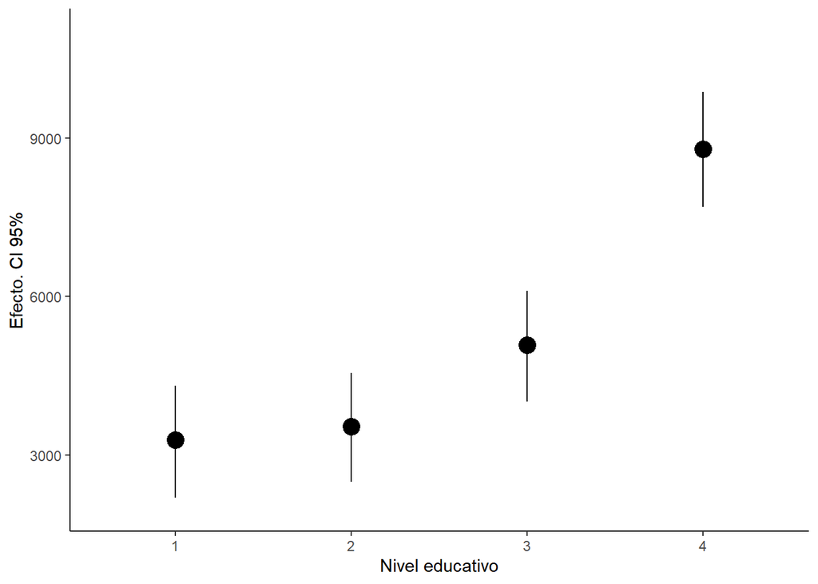

```r
library(ggeffects)
E1<-ggpredict(M4, terms = c("niv_edexpjh_1 [1]"))
E2<-ggpredict(M4, terms = c("niv_edexpjh_2 [1]"))
E3<-ggpredict(M4, terms = c("niv_edexpjh_3 [1]"))
E4<-ggpredict(M4, terms = c("niv_edexpjh_4 [1]"))

p<-rbind(E1,E2,E3,E4)
p$nivel<-c(1,2,3,4)

ggplot(p, aes(x = reorder(nivel,predicted), y = predicted)) +
  geom_point(position=position_dodge(width=.3)) +
  geom_pointrange(aes(ymin = conf.low, ymax = conf.high), fatten = 8, position=position_dodge(width=.3)) + labs(x="Nivel educativo", y="Efecto. CI 95%") +
   ylim(c(2000,11000))  +
  theme_classic() + theme(legend.position = "bottom")
```

## OK PERO ERROR DE PRINCIPIANTE… Cómo se distribuye el ingreso?

Ah!!! Fatal! Así no podemos seguir. Deberíamos usar el viejo truco de sacarle el logaritmo?

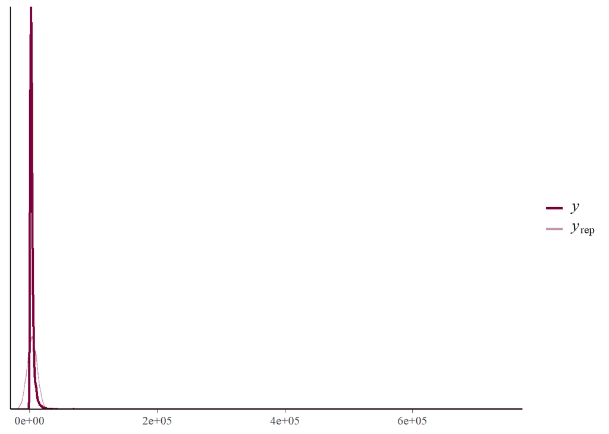

```r
pp_check(M4)
```

Recuerden que Bayes es mucho más flexible. Vamos a usar `family=skew_normal()`.

```r
M5.b<-brm(ictpc ~ 1 + niv_edexpjh_1 + niv_edexpjh_2 + niv_edexpjh_3 + niv_edexpjh_4 + tamhogesc + ent_10 + ent_11 + ent_12  + ent_13 + ent_14 + ent_15 +          ent_16 + ent_17 + ent_18 + ent_19 + ent_2 + ent_20 + ent_21 +   ent_22   + ent_23 + ent_24  + ent_25 + ent_26  +  ent_27 +  ent_28 +  ent_29 +         ent_3  + ent_30  + ent_31 +   ent_32 + ent_4  +   ent_5  + ent_6 + ent_7 +   ent_8 + ent_9  + tam_loc_1 +  tam_loc_2 + tam_loc_3  +
tam_loc_4, family=skew_normal(),
          prior = c(set_prior("normal(0,10000)", class = "b")),
          iter=2000, cores = 2, chains=2, init=0, data=D, threads = threading(8, grainsize = 100),backend = "cmdstanr")
```

```
## Running MCMC with 2 parallel chains, with 8 thread(s) per chain...
##
## Chain 1 Iteration:    1 / 2000 [  0%]  (Warmup)
## Chain 2 Iteration:    1 / 2000 [  0%]  (Warmup)
## Chain 1 Iteration:  100 / 2000 [  5%]  (Warmup)
## Chain 2 Iteration:  100 / 2000 [  5%]  (Warmup)
## Chain 2 Iteration:  200 / 2000 [ 10%]  (Warmup)
## Chain 1 Iteration:  200 / 2000 [ 10%]  (Warmup)
## Chain 2 Iteration:  300 / 2000 [ 15%]  (Warmup)
## Chain 1 Iteration:  300 / 2000 [ 15%]  (Warmup)
## Chain 2 Iteration:  400 / 2000 [ 20%]  (Warmup)
## Chain 1 Iteration:  400 / 2000 [ 20%]  (Warmup)
## Chain 2 Iteration:  500 / 2000 [ 25%]  (Warmup)
## Chain 1 Iteration:  500 / 2000 [ 25%]  (Warmup)
## Chain 2 Iteration:  600 / 2000 [ 30%]  (Warmup)
## Chain 1 Iteration:  600 / 2000 [ 30%]  (Warmup)
## Chain 2 Iteration:  700 / 2000 [ 35%]  (Warmup)
## Chain 1 Iteration:  700 / 2000 [ 35%]  (Warmup)
## Chain 2 Iteration:  800 / 2000 [ 40%]  (Warmup)
## Chain 1 Iteration:  800 / 2000 [ 40%]  (Warmup)
## Chain 2 Iteration:  900 / 2000 [ 45%]  (Warmup)
## Chain 1 Iteration:  900 / 2000 [ 45%]  (Warmup)
## Chain 2 Iteration: 1000 / 2000 [ 50%]  (Warmup)
## Chain 2 Iteration: 1001 / 2000 [ 50%]  (Sampling)
## Chain 1 Iteration: 1000 / 2000 [ 50%]  (Warmup)
## Chain 1 Iteration: 1001 / 2000 [ 50%]  (Sampling)
## Chain 2 Iteration: 1100 / 2000 [ 55%]  (Sampling)
## Chain 2 Iteration: 1200 / 2000 [ 60%]  (Sampling)
## Chain 1 Iteration: 1100 / 2000 [ 55%]  (Sampling)
## Chain 2 Iteration: 1300 / 2000 [ 65%]  (Sampling)
## Chain 1 Iteration: 1200 / 2000 [ 60%]  (Sampling)
## Chain 2 Iteration: 1400 / 2000 [ 70%]  (Sampling)
## Chain 1 Iteration: 1300 / 2000 [ 65%]  (Sampling)
## Chain 2 Iteration: 1500 / 2000 [ 75%]  (Sampling)
## Chain 1 Iteration: 1400 / 2000 [ 70%]  (Sampling)
## Chain 2 Iteration: 1600 / 2000 [ 80%]  (Sampling)
## Chain 1 Iteration: 1500 / 2000 [ 75%]  (Sampling)
## Chain 2 Iteration: 1700 / 2000 [ 85%]  (Sampling)
## Chain 2 Iteration: 1800 / 2000 [ 90%]  (Sampling)
## Chain 1 Iteration: 1600 / 2000 [ 80%]  (Sampling)
## Chain 2 Iteration: 1900 / 2000 [ 95%]  (Sampling)
## Chain 1 Iteration: 1700 / 2000 [ 85%]  (Sampling)
## Chain 2 Iteration: 2000 / 2000 [100%]  (Sampling)
## Chain 2 finished in 640.7 seconds.
## Chain 1 Iteration: 1800 / 2000 [ 90%]  (Sampling)
## Chain 1 Iteration: 1900 / 2000 [ 95%]  (Sampling)
## Chain 1 Iteration: 2000 / 2000 [100%]  (Sampling)
## Chain 1 finished in 717.8 seconds.
##
## Both chains finished successfully.
## Mean chain execution time: 679.2 seconds.
## Total execution time: 718.0 seconds.
```

```r
summary(M5.b)
```

```
##  Family: skew_normal
##   Links: mu = identity; sigma = identity; alpha = identity
## Formula: ictpc ~ 1 + niv_edexpjh_1 + niv_edexpjh_2 + niv_edexpjh_3 + niv_edexpjh_4 + tamhogesc + ent_10 + ent_11 + ent_12 + ent_13 + ent_14 + ent_15 + ent_16 + ent_17 + ent_18 + ent_19 + ent_2 + ent_20 + ent_21 + ent_22 + ent_23 + ent_24 + ent_25 + ent_26 + ent_27 + ent_28 + ent_29 + ent_3 + ent_…
##    Data: D (Number of observations: 20000)
##   Draws: 2 chains, each with iter = 2000; warmup = 1000; thin = 1;
##          total post-warmup draws = 2000
##
## Population-Level Effects:
##               Estimate Est.Error  l-95% CI u-95% CI Rhat Bulk_ESS Tail_ESS
## Intercept      6984.46   5165.40  -3046.49 17626.31 1.00      368      566
## niv_edexpjh_1    83.83     50.58    -15.02   184.20 1.00      757      981
## niv_edexpjh_2   233.18     47.31    141.26   329.74 1.00      700      998
## niv_edexpjh_3   423.95     62.00    300.37   545.52 1.00      675     1085
## niv_edexpjh_4  1148.58     61.99   1026.83  1268.86 1.00      663     1202
## tamhogesc       -36.30     11.99    -58.97   -12.28 1.00      995     1307
## ent_10         -392.46    131.02   -657.34  -149.28 1.01      238      612
## ent_11          -45.92    119.43   -285.15   185.01 1.01      209      383
## ent_12         -472.23    140.63   -758.16  -212.96 1.00      311      684
## ent_13           56.20    134.58   -224.08   300.49 1.00      272      736
## ent_14          244.13    115.64      9.44   464.09 1.00      260      618
## ent_15         -116.37    126.81   -370.97   120.45 1.00      245      685
## ent_16          -61.55    133.72   -327.47   203.43 1.00      288      790
## ent_17         -393.12    141.96   -672.50  -117.57 1.00      322      669
## ent_18          -11.61    127.11   -258.42   232.70 1.00      271      562
## ent_19          440.39    116.94    210.50   663.03 1.00      226      389
## ent_2            15.63    121.09   -212.90   261.25 1.00      285      810
## ent_20         -423.82    139.99   -709.27  -167.54 1.01      237      686
## ent_21         -222.62    131.77   -484.40    31.68 1.00      220      607
## ent_22          134.88    113.73    -85.69   345.66 1.01      187      488
## ent_23           97.87    140.92   -181.74   369.52 1.00      335      836
## ent_24         -226.82    133.88   -505.51    32.20 1.00      229      683
## ent_25          191.22    113.03    -28.95   412.18 1.00      183      466
## ent_26          -15.51    130.66   -276.47   241.48 1.00      310      672
## ent_27         -232.22    135.72   -499.60    28.35 1.01      230      707
## ent_28         -273.22    134.58   -557.46   -23.18 1.00      251      560
## ent_29         -357.51    143.86   -652.91   -96.64 1.00      292      857
## ent_3           185.80    123.66    -60.17   437.61 1.00      241      707
## ent_30         -373.52    137.90   -661.90  -109.76 1.01      215      589
## ent_31          -84.67    127.31   -344.82   160.00 1.00      218      522
## ent_32         -157.07    129.32   -412.81    89.15 1.00      204      623
## ent_4          -198.11    130.16   -463.63    52.22 1.01      261      673
## ent_5            40.09    119.10   -191.41   274.65 1.00      268      630
## ent_6          -104.45    118.45   -335.82   118.64 1.00      219      745
## ent_7          -516.30    142.20   -807.31  -244.27 1.00      291      742
## ent_8          -132.43    110.71   -348.43    85.78 1.01      204      553
## ent_9           103.49    125.80   -156.42   331.28 1.01      247      669
## tam_loc_1       354.04   5167.06 -10264.57 10459.58 1.00      369      564
## tam_loc_2       126.47   5166.37 -10508.60 10210.97 1.00      369      562
## tam_loc_3        38.36   5165.32 -10571.87 10130.95 1.00      369      533
## tam_loc_4      -111.33   5166.43 -10683.57 10038.41 1.00      369      564
##
## Family Specific Parameters:
##       Estimate Est.Error l-95% CI u-95% CI Rhat Bulk_ESS Tail_ESS
## sigma  5129.26     26.17  5080.60  5180.21 1.00      657     1018
## alpha    28.53      1.37    26.02    31.46 1.00      797     1225
##
## Draws were sampled using sample(hmc). For each parameter, Bulk_ESS
## and Tail_ESS are effective sample size measures, and Rhat is the potential
## scale reduction factor on split chains (at convergence, Rhat = 1).
```

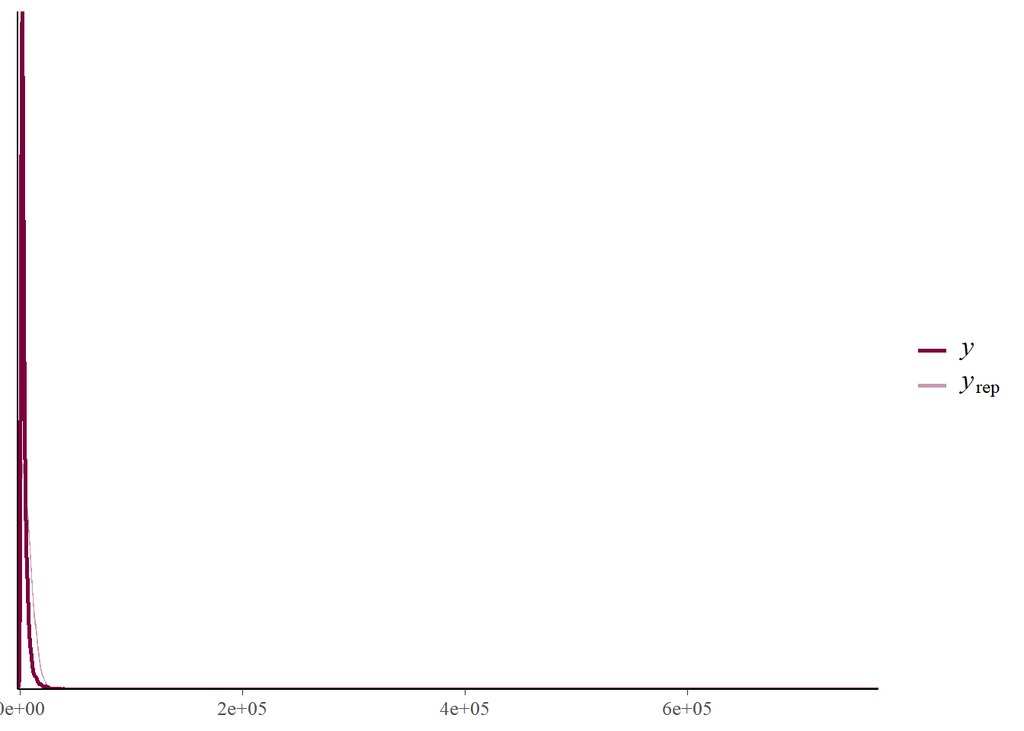

```r
pp_check(M5.b)
```

Hipótesis con la función `hypothesis`. Primero definimos la hip[otesis. Por ejemplo, que los efectos son iguales.

```r
## perform two-sided hypothesis testing
(hyp1 <- hypothesis(M5.b, "niv_edexpjh_1 = niv_edexpjh_4"))
```

```
## Hypothesis Tests for class b:
##                 Hypothesis Estimate Est.Error CI.Lower CI.Upper Evid.Ratio
## 1 (niv_edexpjh_1)-(... = 0 -1064.75     58.78    -1179  -946.33         NA
##   Post.Prob Star
## 1        NA    *
## ---
## 'CI': 90%-CI for one-sided and 95%-CI for two-sided hypotheses.
## '*': For one-sided hypotheses, the posterior probability exceeds 95%;
## for two-sided hypotheses, the value tested against lies outside the 95%-CI.
## Posterior probabilities of point hypotheses assume equal prior probabilities.
```

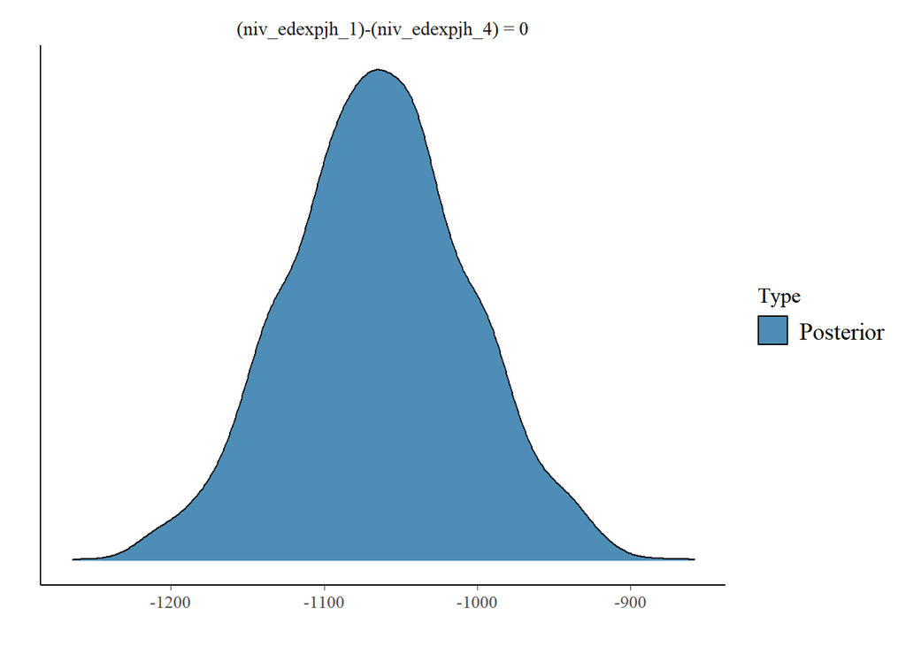

```r
plot(hyp1)
```

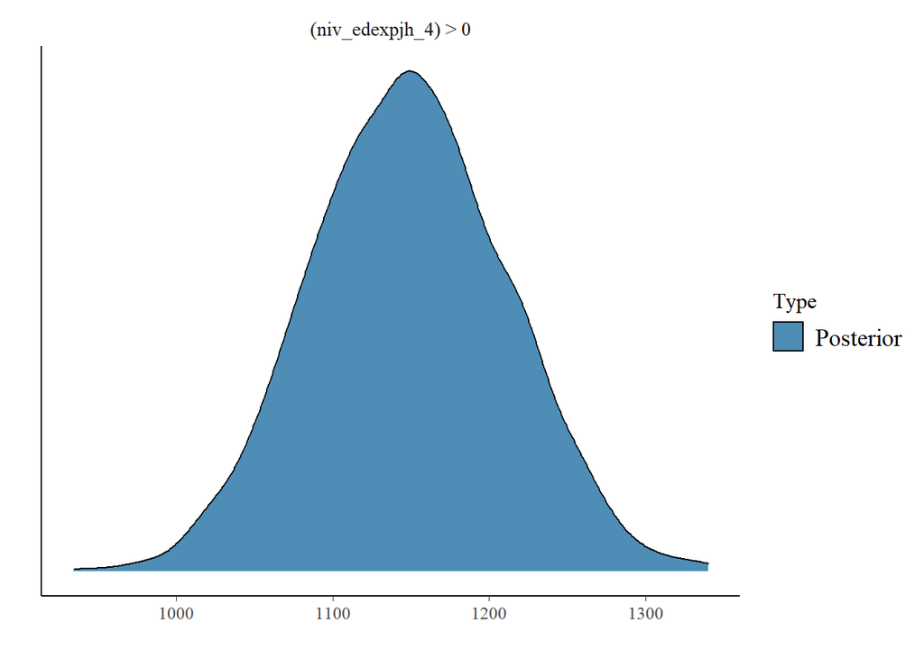

```r
hyp2 <-hypothesis(M5.b, "niv_edexpjh_4 > 0", alpha = 0.01)
plot(hyp2)
```

Qué tal y si nos preguntamos que ir a la universidad incrementa en 800 pesos per capita el ingreso del hogar (respecto a no terminar la primaria).

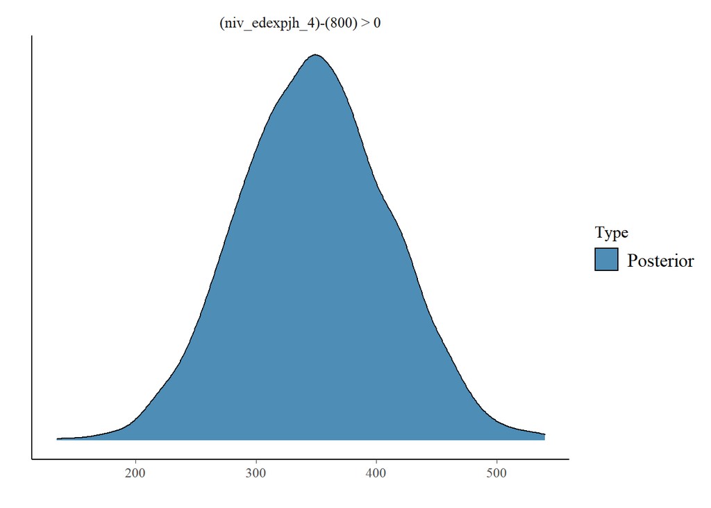

```r
hyp2 <-hypothesis(M5.b, "niv_edexpjh_4 > 800", alpha = 0.01)
plot(hyp2)
```

Es igual el efecto entre CDMX y NL?

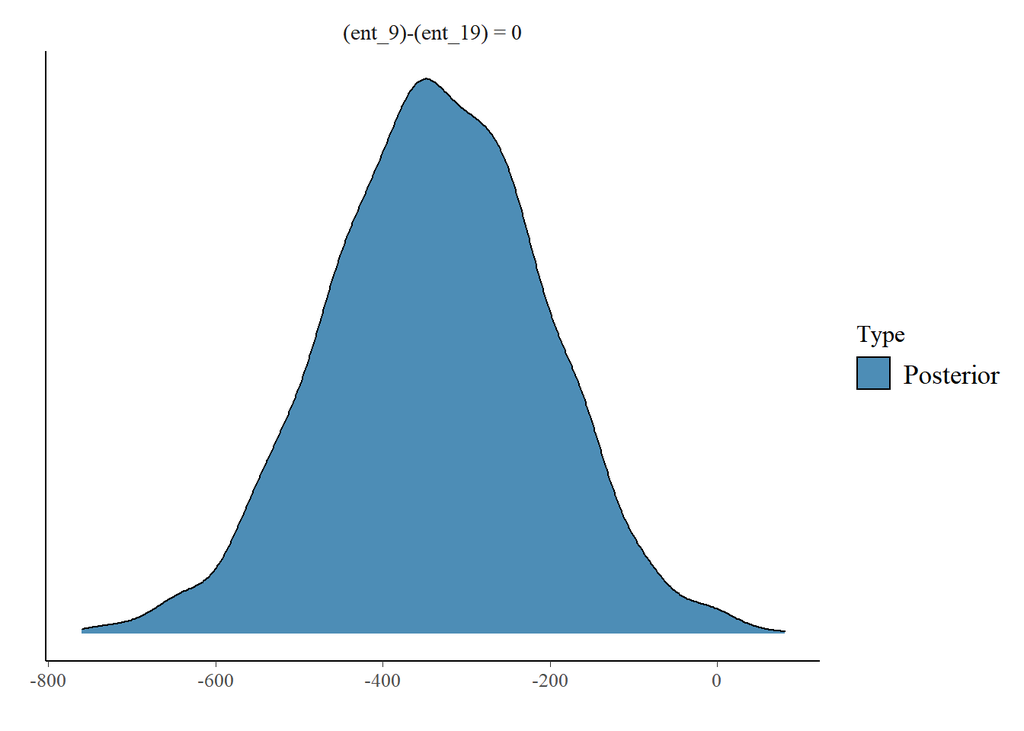

```r
hyp3 <-hypothesis(M5.b, "ent_9 = ent_19", alpha = 0.01)
plot(hyp3)
```

Reducción del tamaño del hogar

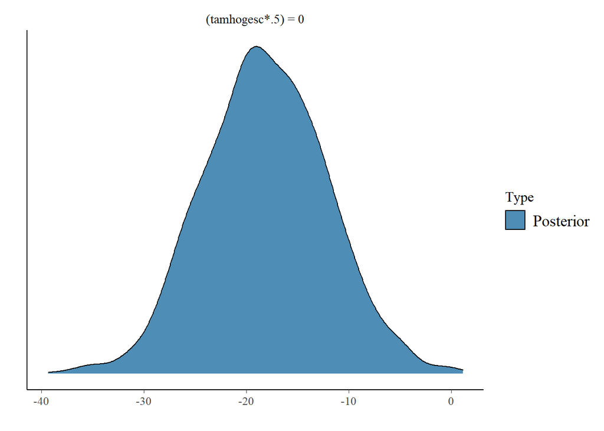

```r
hyp4 <-hypothesis(M5.b, "tamhogesc*.5  = 0", alpha = 0.01)
plot(hyp4)
```